# Project 2: Creating a Vignette for API Interactions

Angelice Floyd 2023-10-10

- Introduction
- Requirements
- Public Assistance Funded Projects Endpoint
- Individual Assistance for Homeowners
- Emergency Management Performance Grant
- Data Exploration
  - Public Assistance Funded Projects
    - Data pulls
    - Contingency Tables
    - Numerical Summaries
    - Plots
  - Individual Assistance for Homeowners
    - Numerical Summaries
    - Plots
  - Emergency Management Performance Grants
    - Numerical Summaries
    - Plots
- Wrap Up

This line of code creates the render function for R to be able to run wihout hitting the “Knit” button.

```r
rmarkdown::render("Project2.Rmd",
              output_format = "github_document",
              output_options = list(
                name_value_pairs = "value",
                toc = TRUE,
                toc_depth = 4,
                number_of_sections = TRUE,
                df_print = "paged",
                or_something = TRUE
                )
              )
```

Contents

- Intro and Requirements
- Functions for API Interaction
  - `PAData`
  - `PNUMData`
  - `IAData`
  - `EMPData`
- Data Exploration
- Wrap- Up

#Introduction and Requirements

## Introduction

This project creates a vignette for reading and summarizing data from a FEMA ( Federal Emergency Management Agency) API. The first section will consist of pulling in all of the necessary libraries needed to run the R program, contact the API from the FEMA webiste, and create the exploratory data analysis from the data. The second section will create the functions for interacting with the API. The Third section will use the data from the API function interaction for some exploratory data analysis. Finally, there will be a wrap up to summarize what was done in the vignette.

## Requirements

This section loads the packages required for interacting with the FEMA API, manipulating the data, and conducting exploratory data analysis.

```r
library(tidyverse)
library(httr)
library(jsonlite)
```

#Functions for API Interactions

## [Public Assistance Funded Projects Endpoint](https://www.fema.gov/openfema-data-page/public-assistance-funded-project-summaries-v1)

The first function created interacts with the Public Assistance endpoint of the FEMA API. This data contiains numerical and categorical summary information on funding projects that FEMA conducted geared towards public assistance. For consistency and use in later analysis, the two state abbreviation was created. This function is designed to filter the data by full state name. Thus, if a string that is not a valid state name ( or the name is not available) is entered, an error message will appear prompting you to enter a valid or available state name. One thing that I found interesting about this data was that a large amount of participants were southern states. Thus, some of the main states in the dataset were Texas, Alabama, and Tennessee> there are some states like Colorado and North Dakota, but the majority are southern states.

```r
PAdata <- function(statename = "all") {
  #pull the public assistance summaries from the Public assistance endpoint

  outputAPI <- fromJSON(
    "https://www.fema.gov/api/open/v1/PublicAssistanceFundedProjectsSummaries"
    )

   APIData <- outputAPI$PublicAssistanceFundedProjectsSummaries %>%
     mutate(stateabb = state.abb[match(state,state.name)])

   #If the default state name of 'all' is not included, then make sure that the
   #chosen name is included, and filter, otherwise, print out an error
   if(statename != "all"){
     if(statename %in% APIData$state) {
       output <- APIData %>% filter(state == statename)
     }
     else{
       message <- print("Please try again and enter a valid state name")
       stop(message)
     }
   }
   else{
     output <- APIData
   }
  return(output)
}

PAdata()
```

|  | disasterNumber | declarationDate | incidentType | state | county | applicantName | educationApplicant | numberOfProjects | federalObligatedAmount | lastRefresh | hash | id | stateabb |
| --- | --- | --- | --- | --- | --- | --- | --- | --- | --- | --- | --- | --- | --- |
| 1 | 1239 | 1998-08-26T00:00:00.000Z | Severe Storm | Texas | Edwards | EDWARDS (COUNTY) | FALSE | 20 | 352427.09 | 2023-03-18T17:02:48.443Z | a18872962143d707fb83e3f0b054abda40413d04 | 0646e381-ea0a-46e5-993d-1bdb1cfe2a27 | TX |
| 2 | 1239 | 1998-08-26T00:00:00.000Z | Severe Storm | Texas | Kimble | JUNCTION, CITY OF | FALSE | 1 | 6234.90 | 2023-03-18T17:02:48.443Z | d1c77a224203725a79d26a1d84f8ad2b06b36c7f | bc05fe25-0f1e-4344-a120-55f23f45cd4e | TX |
| 3 | 1239 | 1998-08-26T00:00:00.000Z | Severe Storm | Texas | Kimble | KIMBLE (COUNTY) | FALSE | 5 | 69933.35 | 2023-03-18T17:02:48.443Z | 7fb2d6dd706512236b3ed6c0e6ddd6a633b50d38 | d9c845c8-5db4-404b-866d-e06b3c73397a | TX |
| 4 | 1239 | 1998-08-26T00:00:00.000Z | Severe Storm | Texas | Kimble | TEXAS TECH UNIVERSITY CTR | TRUE | 1 | 2850.00 | 2023-03-18T17:02:48.443Z | 571fab79609fe373f64529b540289ee5dd400ed5 | 9350e760-64da-4931-ace0-0e37d7e82eb3 | TX |
| 5 | 1239 | 1998-08-26T00:00:00.000Z | Severe Storm | Texas | Kinney | FORT CLARK MUNICIPAL UTILITY | FALSE | 1 | 5016.00 | 2023-03-18T17:02:48.443Z | 39207f1c57e1f088bef0ce07238c1aa9a18022d8 | a196ef51-9883-47c8-809d-1d797e8e1f48 | TX |
| 6 | 1239 | 1998-08-26T00:00:00.000Z | Severe Storm | Texas | Kinney | KINNEY (COUNTY) | FALSE | 8 | 248569.77 | 2023-03-18T17:02:48.443Z | c40a42519f16f555bf7a5dcf0b80e9b9822c4a20 | 39de6538-b22a-4f4d-9bc5-e8331fae5754 | TX |
| 7 | 1239 | 1998-08-26T00:00:00.000Z | Severe Storm | Texas | Kinney | SPOFFORD | FALSE | 1 | 3842.44 | 2023-03-18T17:02:48.443Z | 27a47496ec86dfe6040e1e990fe2a7e629004e1d | a7b65c71-04ad-42cb-bf3b-5a9171b890d1 | TX |
| 8 | 1239 | 1998-08-26T00:00:00.000Z | Severe Storm | Texas | Maverick | EAGLE PASS | FALSE | 11 | 260653.76 | 2023-03-18T17:02:48.443Z | eb5abec160a33b3d2bf0a6f9eaa08295e9a698a9 | 1ce2637e-8b52-4c80-b393-72a2b498cd51 | TX |
| 9 | 1239 | 1998-08-26T00:00:00.000Z | Severe Storm | Texas | Maverick | EAGLE PASS INDEPENDENT SCHOOL | TRUE | 1 | 4658.78 | 2023-03-18T17:02:48.443Z | f57284709347d5bb5e37c1c209c7a091eabb4c8c | bab5ed18-737b-4604-a286-1c572219c6db | TX |
| 10 | 1239 | 1998-08-26T00:00:00.000Z | Severe Storm | Texas | Maverick | MAVERICK (COUNTY) | FALSE | 2 | 8837.25 | 2023-03-18T17:02:48.443Z | 8d5736e71037dc2399842f82a355a85d07ee1e91 | 53ca6416-0b75-4c84-9eed-af4c59460502 | TX |

[output cut: 990 more lines]

This next set of code modifies the endpoint to filter on pulling data from either the full state name, the county name of the region, or the two letter abbreviated state name. Thus, the user could type in state name and the data filters on the state name value. However, if the user chooses to type in either the two letter state name or the county name, the API modifies to filter on the given value. Further, all of this can be typed in as one string under statename, where the default is all state values. Finally, the output pulls all of the relevant variables that will be used in the Exploratory Data analysis.

```r
PNUMData <- function(statename = "all") {

  outputAPI <- fromJSON(
    "https://www.fema.gov/api/open/v1/PublicAssistanceFundedProjectsSummaries")
  APIData <- outputAPI$PublicAssistanceFundedProjectsSummaries %>%
    mutate(stateabb = state.abb[match(state,state.name)])
  output <- APIData

  if(statename != "all"){

    if(statename %in% APIData$state) {

      output <- APIData %>% filter(state == statename)
    }

    else if( statename %in% APIData$county) {

      #Initial URL for the API
      URL1 <- "https://www.fema.gov/api/open/v1/"

      #Extended endpoint with the county filter
      endpoint <- "PublicAssistanceFundedProjectsSummaries?$filter=county%20eq"

      #final URL that will putll the above data
      finURL <- paste0(URL1, endpoint,paste('%20%27',statename,'%27',sep=""),sep="")

      #Object that creates communicates to the FEMA API
      outputAPI <- fromJSON(finURL)

      #Finally, these objects create the dataset for the API Data
      output <- outputAPI$PublicAssistanceFundedProjectsSummaries
    }

   else if(length(statename) == 1) {
     short <- state.name[match(statename,state.abb)]

     #Initial URL for the API
     URL1 <- "https://www.fema.gov/api/open/v1/"

     #Extended endpoint with the county filter
     endpoint <- "PublicAssistanceFundedProjectsSummaries?$filter=state%20eq"

     #final URL that will putll the above data
     finURL <- paste0(URL1, endpoint,paste('%20%27',short,'%27',sep=""),sep="")

     #Object that creates communicates to the FEMA API
     outputAPI <- fromJSON(finURL)

     #Finally, these objects create the dataset for the API Data
     output <- outputAPI$PublicAssistanceFundedProjectsSummaries
   }

  }
  else{

  }

  finoutput <- output %>% select(state,county,incidentType,county,educationApplicant,numberOfProjects,federalObligatedAmount)

 return(finoutput)
}

PNUMData()
```

|  | state | county | incidentType | educationApplicant | numberOfProjects | federalObligatedAmount |
| --- | --- | --- | --- | --- | --- | --- |
| 1 | Texas | Edwards | Severe Storm | FALSE | 20 | 352427.09 |
| 2 | Texas | Kimble | Severe Storm | FALSE | 1 | 6234.90 |
| 3 | Texas | Kimble | Severe Storm | FALSE | 5 | 69933.35 |
| 4 | Texas | Kimble | Severe Storm | TRUE | 1 | 2850.00 |
| 5 | Texas | Kinney | Severe Storm | FALSE | 1 | 5016.00 |
| 6 | Texas | Kinney | Severe Storm | FALSE | 8 | 248569.77 |
| 7 | Texas | Kinney | Severe Storm | FALSE | 1 | 3842.44 |
| 8 | Texas | Maverick | Severe Storm | FALSE | 11 | 260653.76 |
| 9 | Texas | Maverick | Severe Storm | TRUE | 1 | 4658.78 |
| 10 | Texas | Maverick | Severe Storm | FALSE | 2 | 8837.25 |

[output cut: 990 more lines]

```r
PNUMData("Lamar")
```

|  | state | county | incidentType | educationApplicant | numberOfProjects | federalObligatedAmount |
| --- | --- | --- | --- | --- | --- | --- |
| 1 | Alabama | Lamar | Severe Storm | FALSE | 4 | 21564.75 |
| 2 | Alabama | Lamar | Severe Storm | FALSE | 1 | 3036.00 |
| 3 | Georgia | Lamar | Severe Storm | FALSE | 3 | 114376.59 |
| 4 | Georgia | Lamar | Severe Storm | FALSE | 2 | 11045.98 |
| 5 | Georgia | Lamar | Severe Storm | FALSE | 1 | 4740.00 |
| 6 | Texas | Lamar | Severe Ice Storm | FALSE | 3 | 65750.06 |
| 7 | Texas | Lamar | Severe Ice Storm | FALSE | 1 | 5907.00 |
| 8 | Texas | Lamar | Severe Ice Storm | FALSE | 43 | 1471812.87 |
| 9 | Texas | Lamar | Severe Ice Storm | FALSE | 2 | 16269.07 |
| 10 | Texas | Lamar | Severe Ice Storm | TRUE | 2 | 18404.87 |

[output cut: 87 more lines]

## [Individual Assistance for Homeowners](https://www.fema.gov/openfema-data-page/housing-assistance-program-data-owners-v2)

This next API Endpoint produces financial data from the FEMA Housing Assistance Program for Homeowners by zip code, county, city, and state for registered states. Since, I will not be excluding any data for the numerical analysis, all of the modifications and connections are done in the same function.The first portion of the code is used to produce an initial connection to the `HousingAssistanceOwners` API. This brings in the data for all of the states, counties, zip codes and cities- this is the default setting for the statename input. If the user chooses not to incorporate all of the regional based data, there are some options that they could type in which correspond to the following :  
* Two letter state abbreviation if the state is registered: ex: AL  
* specific full state name  
* Zip code if the region is registered and in the dataset : This has to be in a character string.  
* City: must be in all capitals.

```r
IAData <- function(statename = "all") {

  outputAPI <- fromJSON(
  "https://www.fema.gov/api/open/v2/HousingAssistanceOwners"
  )

  APIData <- outputAPI$HousingAssistanceOwners %>%
    rename("stateabb"=state) %>%
    mutate(state = state.name[match(stateabb,state.abb)])
  output <- APIData

  #If the default state name of 'all is not included, then make sure that the
  #chosen name is included, and filter, otherwise, print out an error
  if(statename != "all"){
    if(statename %in% APIData$state) {
    output <- APIData %>% filter(state == statename)
    }

  else if( statename %in% APIData$zipCode) {

    #Initial URL for the API
    URL1 <- "https://www.fema.gov/api/open/v2/"

    #Extended endpoint with the zip code filter
    endpoint <- "HousingAssistanceOwners?$filter=zipCode%20eq"

    #final URL that will putll the above data
    finURL <- paste0(URL1, endpoint,paste('%20%27',statename,'%27',sep=""),sep="")

    #Object that creates communicates to the FEMA API
    outputAPI <- fromJSON(finURL)

    #Finally, these objects create the dataset for the API Data
    output <- outputAPI$HousingAssistanceOwners
  }
  else if( statename %in% APIData$city) {

    #Initial URL for the API
    URL1 <- "https://www.fema.gov/api/open/v2/"

    #Extended endpoint with the zip code filter
    endpoint <- "HousingAssistanceOwners?$filter=city%20eq"

    #final URL that will putll the above data
    finURL <- paste0(URL1, endpoint,paste('%20%27',statename,'%27',sep=""),sep="")

    #Object that creates communicates to the FEMA API
    outputAPI <- fromJSON(finURL)

    #Finally, these objects create the dataset for the API Data
    output <- outputAPI$HousingAssistanceOwners
  }

  else if(length(statename) == 1) {
    short <- state.name[match(statename,state.abb)]

    #Initial URL for the API
    URL1 <- "https://www.fema.gov/api/open/v1/"

    #Extended endpoint with the county filter
    endpoint <- "PublicAssistanceFundedProjectsSummaries?$filter=state%20eq"

    #final URL that will putll the above data
    finURL <- paste0(URL1, endpoint,paste('%20%27',short,'%27',sep=""),sep="")

    #Object that creates communicates to the FEMA API
    outputAPI <- fromJSON(finURL)

    #Finally, these objects create the dataset for the API Data
    output <- outputAPI$PublicAssistanceFundedProjectsSummaries
  }

else{

}
  }
  return(output)
}
IAData()
```

|  | disasterNumber | stateabb | county | city | zipCode | validRegistrations | averageFemaInspectedDamage | totalInspected | totalDamage | noFemaInspectedDamage | femaInspectedDamageBetween1And10000 | femaInspectedDamageBetween10001And20000 | femaInspectedDamageBetween20001And30000 | femaInspectedDamageGreaterThan30000 | approvedForFemaAssistance | totalApprovedIhpAmount | repairReplaceAmount | rentalAmount | otherNeedsAmount | approvedBetween1And10000 | approvedBetween10001And25000 | approvedBetween25001AndMax | totalMaxGrants | id | state |
| --- | --- | --- | --- | --- | --- | --- | --- | --- | --- | --- | --- | --- | --- | --- | --- | --- | --- | --- | --- | --- | --- | --- | --- | --- | --- |
| 1 | 1439 | TX | Aransas (County) | ARANSAS PASS | 78335 | 4 | 1345.01 | 3 | 5380.02 | 0 | 3 | 0 | 0 | 0 | 3 | 5915.91 | 3573.02 | 970.00 | 1372.89 | 3 | 0 | 0 | 0 | 0e71510a-3181-440d-b459-a6b0312abfa4 | Texas |
| 2 | 1439 | TX | Aransas (County) | ARANSAS PASS | 78336 | 68 | 3082.82 | 63 | 209632.06 | 4 | 56 | 3 | 0 | 0 | 54 | 180717.57 | 131097.36 | 23946.00 | 25674.21 | 27 | 26 | 1 | 0 | b2fd45e0-8b53-42eb-ad19-37b4df00ea53 | Texas |
| 3 | 1439 | TX | Aransas (County) | FULTON | 78358 | 20 | 4722.34 | 18 | 94446.72 | 0 | 17 | 1 | 0 | 0 | 17 | 94240.88 | 58754.70 | 6784.00 | 28702.18 | 3 | 11 | 3 | 0 | 21e535d1-384d-4e71-91a0-aec94030c9a5 | Texas |
| 4 | 1439 | TX | Aransas (County) | FULTON | 78381 | 1 | 2578.30 | 1 | 2578.30 | 0 | 1 | 0 | 0 | 0 | 1 | 3304.30 | 1407.96 | 726.00 | 1170.34 | 1 | 0 | 0 | 0 | be50303c-4d14-4507-acda-30c9703b7129 | Texas |
| 5 | 1439 | TX | Aransas (County) | ROCKPORT | 78331 | 1 | 0.00 | 0 | 0.00 | 0 | 0 | 0 | 0 | 0 | 0 | 0.00 | 0.00 | 0.00 | 0.00 | 0 | 0 | 0 | 0 | 93bcd38b-8872-4e06-bf6e-0cd62df4ed41 | Texas |
| 6 | 1439 | TX | Aransas (County) | ROCKPORT | 78381 | 16 | 4138.11 | 15 | 66209.78 | 0 | 15 | 0 | 0 | 0 | 13 | 54528.53 | 37005.17 | 5088.00 | 12435.36 | 6 | 6 | 1 | 0 | 502c0db8-c78f-4cb2-8e1d-3a3998bb4a3e | Texas |
| 7 | 1439 | TX | Aransas (County) | ROCKPORT | 78382 | 307 | 3653.90 | 278 | 1121747.18 | 10 | 252 | 15 | 0 | 1 | 259 | 1069191.44 | 711228.83 | 135290.00 | 222672.61 | 118 | 115 | 26 | 0 | 3745e534-f1d4-473f-a61c-9e7a8a0c3792 | Texas |
| 8 | 1439 | TX | Aransas (County) | ROCK PORT | 78358 | 1 | 1540.35 | 1 | 1540.35 | 0 | 1 | 0 | 0 | 0 | 1 | 5726.00 | 5000.00 | 726.00 | 0.00 | 0 | 1 | 0 | 0 | 9a7cd47f-cb30-4527-84b9-b5a037429692 | Texas |
| 9 | 1439 | TX | Aransas (County) | TAFT | 78390 | 1 | 3581.76 | 1 | 3581.76 | 0 | 1 | 0 | 0 | 0 | 1 | 3855.33 | 2885.33 | 970.00 | 0.00 | 0 | 1 | 0 | 0 | 17d08ea1-2ecb-46ec-a500-887307075740 | Texas |
| 10 | 1439 | TX | Brazoria (County) | ALVIN | 77511 | 5 | 4443.00 | 5 | 22214.98 | 1 | 3 | 1 | 0 | 0 | 5 | 15866.20 | 11486.67 | 2600.00 | 1779.53 | 2 | 3 | 0 | 0 | ffe08974-b895-4ed5-91ef-451dab3a87e2 | Texas |

[output cut: 990 more lines]

```r
IAData('99776')
```

|  | disasterNumber | state | county | city | zipCode | validRegistrations | averageFemaInspectedDamage | totalInspected | totalDamage | noFemaInspectedDamage | femaInspectedDamageBetween1And10000 | femaInspectedDamageBetween10001And20000 | femaInspectedDamageBetween20001And30000 | femaInspectedDamageGreaterThan30000 | approvedForFemaAssistance | totalApprovedIhpAmount | repairReplaceAmount | rentalAmount | otherNeedsAmount | approvedBetween1And10000 | approvedBetween10001And25000 | approvedBetween25001AndMax | totalMaxGrants | id |
| --- | --- | --- | --- | --- | --- | --- | --- | --- | --- | --- | --- | --- | --- | --- | --- | --- | --- | --- | --- | --- | --- | --- | --- | --- |
| 1 | 1440 | AK | Denali (Borough) | TANACROSS | 99776 | 4 | 388.26 | 4 | 1553.04 | 1 | 3 | 0 | 0 | 0 | 2 | 1313.83 | 1313.83 | 0 | 0 | 2 | 0 | 0 | 0 | 11999e46-f934-4c5e-91d7-64a9ff431596 |
| 2 | 1440 | AK | Fairbanks North Star (Borough) | TANACROSS | 99776 | 1 | 2089.14 | 1 | 2089.14 | 0 | 1 | 0 | 0 | 0 | 1 | 2089.14 | 2089.14 | 0 | 0 | 1 | 0 | 0 | 0 | 8b98b3b1-0e2c-4e7b-9253-c56365883d00 |

## [Emergency Management Performance Grant](https://www.fema.gov/openfema-data-page/emergency-management-performance-grants-v2)

The final interaction with the FEMA API will be connecting to the Emergency Management Performance Grant endpoint.This produces a dataset that shows the amount of grant funding provided to regional emergency management agencies in order to assist them with their emergency preparedness initiatives during a specific length of time. The modifications to the API will be the state, and the beginning date of the project funded, as it will be interesting to be able to filter the data pertaining to the times where different states conducted their emergency preparedness projects.

First, this set of code creates a list of possible combinations of state names and start dates for reference.

```r
outputAPI <- fromJSON(
  "https://www.fema.gov/api/open/v2/EmergencyManagementPerformanceGrants"
)

APIDataIN <- outputAPI$EmergencyManagementPerformanceGrants %>%
  mutate(stateabb = state.abb[match(state,state.name)]) %>%  separate(projectStartDate,c("startdate","starttime"),sep = "T",convert=TRUE, remove = FALSE) %>% separate(projectEndDate,c("enddate","endtime"), sep = "T", convert = TRUE, remove = FALSE) %>% unite("index",state,startdate, remove = FALSE)


print(tibble(index = unique(APIDataIN$index)) %>% separate(index,c("state","startdate"),sep="_") %>% mutate(stateabb = state.abb[match(state,state.name)]))
```

[output not shown]

Next, this set of code creates a function that pulls the Emergency Management Performance Grant data from the endpoint. There are some options for the user.  
* Enter nothing -`EMPData()`- and all of the data ( unfiltered ) is pulled from the endpoint.  
* Enter the state name ( full or abbreviated), but not the start date - `EMPData(statename = "AL")`, then if the full name is give, the filtered data from the first bullet is output, but if the abbreviated version is given, the full name of the abbreviated version is found and the endpoint is modified to pull from the converted abbreviation and the data from the corresponding state with all possible dates is produced.  
* Enter the start date but not the state name `EMPData(stdate = "2014-10-01")` ,the startdate is first parsed from the projectStartDate variable ( since this variable includes both the startdate and a starttime), united with the starttime, and the endpoint is modified to find the re-combined value within the projectStartDate.  
* If both the state name and start date are entered `EMPData(stdate = "2014-10-01",statename = "AL")`, the program follows the logic of the previous two bullets, and the endpoint is modified to search for the two values.

```r
EMPData <- function(statename = "all",stdate = "all") {

  outputAPI <- fromJSON(
    "https://www.fema.gov/api/open/v2/EmergencyManagementPerformanceGrants"
  )

  APIDataIN <- outputAPI$EmergencyManagementPerformanceGrants %>%
    mutate(stateabb = state.abb[match(state,state.name)]) %>%  separate(projectStartDate,c("startdate","starttime"),sep = "T",convert=TRUE, remove = FALSE) %>% separate(projectEndDate,c("enddate","endtime"), sep = "T", convert = TRUE, remove = FALSE)

  output <- APIDataIN

  #If the default state name of 'all is not included, then make sure that the
  #chosen name is included, and filter, otherwise, print out an error
  if(statename != "all" & stdate == "all"){
    if(statename %in% APIDataIN$state) {
      output <- APIData %>% filter(state == statename)
    }

    else if(length(statename) == 1) {
      short <- state.name[match(statename,state.abb)]

      #Initial URL for the API
      URL1 <- "https://www.fema.gov/api/open/v2/"

      #Extended endpoint with the county filter
      endpoint <- "EmergencyManagementPerformanceGrants?$filter=state%20eq"

      #final URL that will putll the above data
      finURL <- paste0(URL1, endpoint,paste('%20%27',short,'%27',sep=""),sep="")

      #Object that creates communicates to the FEMA API
      outputAPI <- fromJSON(finURL)

      #Finally, these objects create the dataset for the API Data
      output <- outputAPI$EmergencyManagementPerformanceGrants %>%  separate(projectStartDate,c("startdate","starttime"),sep = "T",convert=TRUE, remove = FALSE) %>% separate(projectEndDate,c("enddate","endtime"), sep = "T", convert = TRUE, remove = FALSE)
    }
  }
  else if(stdate != "all" & statename == "all") {
    dateval <- paste0(stdate,"T",APIDataIN$starttime[1])

    #Initial URL for the API
    URL1 <- "https://www.fema.gov/api/open/v2/"

    #Extended endpoint with the county filter
    endpoint <- "EmergencyManagementPerformanceGrants?$filter=projectStartDate%20eq"

    #final URL that will putll the above data
    finURL <- paste0(URL1, endpoint,paste('%20%27',dateval,'%27', sep=""),sep="")

    #Object that creates communicates to the FEMA API
    outputAPI <- fromJSON(finURL)

    #Finally, these objects create the dataset for the API Data
    output <- outputAPI$EmergencyManagementPerformanceGrants %>%  separate(projectStartDate,c("startdate","starttime"),sep = "T",convert=TRUE, remove = FALSE) %>% separate(projectEndDate,c("enddate","endtime"), sep = "T", convert = TRUE, remove = FALSE)

  }
    else if(stdate != "all" & statename != "all"){
      if(statename %in% APIDataIN$state){
        dateval <- paste0(stdate,"T",APIData$starttime[1])

      #Initial URL for the API
      URL1 <- "https://www.fema.gov/api/open/v2/"

      #Extended endpoint with the county filter
      endpoint <- "EmergencyManagementPerformanceGrants?$filter=projectStartDate%20eq"

      #final URL that will putll the above data
      finURL <- paste0(URL1, endpoint,paste('%20%27',dateval,'%27%20and%20state%20eq%20%27',statename,"%27",sep=""),sep="")


      #Object that creates communicates to the FEMA API
      outputAPI <- fromJSON(finURL)

      #Finally, these objects create the dataset for the API Data
      output <- outputAPI$EmergencyManagementPerformanceGrants %>%  separate(projectStartDate,c("startdate","starttime"),sep = "T",convert=TRUE, remove = FALSE) %>% separate(projectEndDate,c("enddate","endtime"), sep = "T", convert = TRUE, remove = FALSE)

    }
  else if(length(statename)==1){
    #Take the start date given value and convert it into the Project start Date format

    dateval <- paste0(stdate,"T",APIDataIN$starttime[1])
    long <- state.name[match(statename,state.abb)]

    #Initial URL for the API
    URL1 <- "https://www.fema.gov/api/open/v2/"

    #Extended endpoint with the county filter
    endpoint <- "EmergencyManagementPerformanceGrants?$filter=projectStartDate%20eq"

    #final URL that will putll the above data
    finURL <- paste0(URL1, endpoint,paste('%20%27',dateval,'%27%20and%20state%20eq%20%27',long,"%27",sep=""),sep="")

    #Object that creates communicates to the FEMA API
    outputAPI <- fromJSON(finURL)

    #Finally, these objects create the dataset for the API Data
    output <- outputAPI$EmergencyManagementPerformanceGrants
  }
}
  return(output)
}
```

Below are examples of the options available to the user for this function.

```r
EMPData()
EMPData(statename = "AK")
EMPData(statename = "Alaska")
EMPData(stdate = "2014-07-01")
EMPData(stdate = "2014-07-01",statename = "AK")
EMPData(stdate = "2014-07-01",statename = "Alaska")
```

[output not shown]

# Data Exploration

This section will do some basic exploratory data analysis for the data from each endpoint.

## Public Assistance Funded Projects

Before the EDA is performed, there were some questions that I had. Which disaster type corresponded with the highest amount of federal obligated amount of funding? Which distaster type held the higher amount of frequencies per registered state? Were there more projects conducted for grants in certain states? Did the level of educational applications ( whether or not the primary reason for the application was for educational purposes , TRUE = Yes, FALSE = No) correspond to higher or lower amounts of grant funding (Federal Obligate Amount Variable) ? Is there a relationship between higher levels of funding and higher numbers of projects.

### Data pulls

First, I will conduct a pull of the PNUMData where the education Applicant value is TRUE and the disaster type is a Severe storm or Flood.

```r
numdata <- PNUMData()
numdata %>% filter(educationApplicant==TRUE & incidentType %in% c('Severe Storm','Flood'))
```

| state | county | incidentType | educationApplicant | numberOfProjects | federalObligatedAmount |
| --- | --- | --- | --- | --- | --- |
| Texas | Kimble | Severe Storm | TRUE | 1 | 2850.00 |
| Texas | Maverick | Severe Storm | TRUE | 1 | 4658.78 |
| Texas | Val Verde | Severe Storm | TRUE | 14 | 240463.45 |
| Texas | Webb | Severe Storm | TRUE | 1 | 8047.54 |
| Texas | Austin | Flood | TRUE | 1 | 194858.04 |
| Texas | Bexar | Flood | TRUE | 4 | 8604.75 |
| Texas | Bexar | Flood | TRUE | 2 | 47341.50 |
| Texas | Bexar | Flood | TRUE | 2 | 7390.99 |
| Texas | Bexar | Flood | TRUE | 10 | 61945.32 |
| Texas | Burleson | Flood | TRUE | 11 | 1041286.16 |

[output cut: 32 more lines]

Second, the below code pulls the PNUMData where the Federal Grant Amount is greater than $1,000,000 and the Number of projects is less than 10. I was surprised that there were so many instances were there were very few numbers of Projects that corresponded to large grants. It would be interesting to see what those projects consisted of.

```r
numdata %>% filter(federalObligatedAmount > 1000000 & numberOfProjects < 10 )
```

| state | county | incidentType | educationApplicant | numberOfProjects | federalObligatedAmount |
| --- | --- | --- | --- | --- | --- |
| Texas | Guadalupe | Flood | FALSE | 9 | 1320514 |
| Louisiana | Claiborne | Severe Storm | FALSE | 6 | 1204999 |
| Oklahoma | Cleveland | Tornado | TRUE | 7 | 1218394 |
| Oklahoma | Grady | Tornado | FALSE | 8 | 8737998 |
| Oklahoma | Statewide | Tornado | FALSE | 4 | 1002864 |
| Tennessee | Davidson | Severe Storm | FALSE | 3 | 1469521 |
| North Dakota | Benson | Flood | FALSE | 6 | 1805084 |

### Contingency Tables

```r
table(numdata$state,numdata$incidentType)
```

```
##
##                Flood Severe Ice Storm Severe Storm Tornado
##   Alabama          0                0           73       0
##   Arkansas         0                0           46       0
##   Colorado         0                0           44       0
##   Georgia          0                0            7       0
##   Illinois         0                0           25       0
##   Iowa             0                0           87       0
##   Kansas           0                0            0      13
##   Louisiana        0                0           59       0
##   Mississippi      0               93            0       0
##   North Dakota    35                0            0       0
##   Oklahoma         0                0            0      78
##   Tennessee        0                0          192       0
##   Texas          187                0           40      14
##   Wyoming          0                7            0       0
```

The second contingency table explores how the frequency of the levels of educationApplicants corresponded to the states. As can be seen in the results, the FALSE level (instances where the application was not filled out solely for educational purposes) contained the highest amount of frequencies than the cases where the purpose was solely educatoinal.

```r
table(numdata$state,numdata$educationApplicant)
```

```
##
##                FALSE TRUE
##   Alabama         71    2
##   Arkansas        42    4
##   Colorado        42    2
##   Georgia          6    1
##   Illinois        22    3
##   Iowa            85    2
##   Kansas          11    2
##   Louisiana       57    2
##   Mississippi     92    1
##   North Dakota    34    1
##   Oklahoma        62   16
##   Tennessee      187    5
##   Texas          220   21
##   Wyoming          7    0
```

### Numerical Summaries

To Explore the question for whether a disaster type corresponded to a larger level of funding, the below code will display the mean, max, and min values of funding for each storm type. From the results, it can be seen that the Tornado storm type obtained the highest average funding out of all of the storm types, it also had the highest maximum amount of funding, which would make sense seeing that the damage done from a tornado is highly catastrophic, so larger grant funding to address issues surrounding that type of disaster would be reasonable.

```r
numdata %>% summarize(MinFunding = min(federalObligatedAmount),MeanFunding = mean(federalObligatedAmount), MaxFunding = max(federalObligatedAmount), .by=incidentType)
```

| incidentType | MinFunding | MeanFunding | MaxFunding |
| --- | --- | --- | --- |
| Severe Storm | 750.0 | 122340.22 | 5679897.8 |
| Flood | 985.5 | 189828.76 | 3434775.6 |
| Severe Ice Storm | 750.0 | 73638.61 | 593604.7 |
| Tornado | -123699.2 | 421249.57 | 8737997.9 |

To explore the question of whether there were more projects conducted for grants in certain states, below is a table of the minimum, average and maximum number of projects in each state. Based on the results, even though Texas has the highest maximum number of projects, North Dakota held the higest average amount of projects ( though marginally higher than Texas).

```r
numsum <- numdata %>% summarize(MinNumProjects = min(numberOfProjects),MeanNumProjects = mean(numberOfProjects), MaxFNumProjects = max(numberOfProjects), .by=state)
numsum %>% arrange(desc(MeanNumProjects))
```

| state | MinNumProjects | MeanNumProjects | MaxFNumProjects |
| --- | --- | --- | --- |
| North Dakota | 1 | 9.514286 | 69 |
| Texas | 1 | 9.153527 | 84 |
| Colorado | 1 | 7.250000 | 72 |
| Arkansas | 1 | 6.978261 | 43 |
| Iowa | 1 | 6.103448 | 29 |
| Kansas | 1 | 6.000000 | 24 |
| Georgia | 1 | 5.857143 | 22 |
| Oklahoma | 1 | 5.192308 | 43 |
| Tennessee | 1 | 4.447917 | 45 |
| Louisiana | 1 | 3.406780 | 28 |

[output cut: 4 more lines]

### Plots

To answer the question for which the education applicant level corresponded the highest level of funding, below will show a bar graph of funding per incident for each eaducation level. As can be seen in each of the disaster types, the educationalApplicant level of False, where the purpose of the application was not solely for educational purposes, obtained more funding than the level where the purpose was solely for education. However, it was interesting to see that the Tornado incident type had the highest level of funding for educational applicants out of all of the incident types.

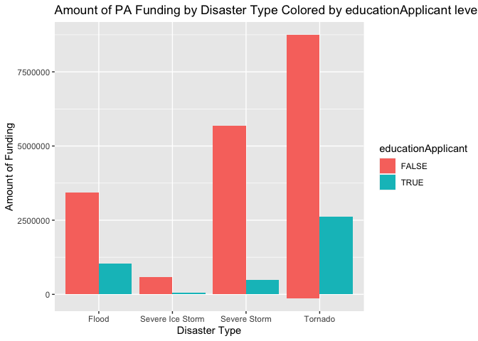

```r
 ggplot(data=numdata, aes(x=incidentType,y=federalObligatedAmount, fill =educationApplicant )) +
  geom_bar(stat = "identity",position= position_dodge()) +
  labs(x = "Disaster Type", y= "Amount of Funding", title= "Amount of PA Funding by Disaster Type Colored by educationApplicant level")
```

To answer the question of whether there is a relationship between amounts of funding and numbers of projects, below is a scatter plot. After separating the results by incident, Flooding seemed to have the clearest relationship between the number of projects and the funding- in which it seems like there is a small ( almost negligible) positive relationship between the number of projects and grant amount. Whereas, for the other incident types, most of the data is clustered at the lower end , with a few outliers that are at the middle level and correspond to higher levels of funding, as can be seen in the Severe Storm plot.

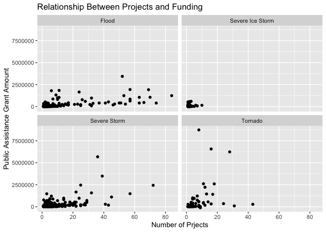

```r
 ggplot(data= numdata, aes(x=numberOfProjects,y= federalObligatedAmount)) +
  geom_point(position= "identity") +
  labs(x = "Number of Prjects", y= "Public Assistance Grant Amount", title= "Relationship Between Projects and Funding") +
  facet_wrap(~incidentType)
```

## Individual Assistance for Homeowners

This data contains information about the number of applicants who had disaster damage at the levels of no damage, damage between $1.00 - $10,000 , between $10,001-$20,000, between $20,001-$30,000 and above $30,000. Thus, I would be interested to see what are the counts of applicants for each of those levels at each state. I would also like to see some summary statistics for the amount of funding for repair/Replace, rental and other needs grants that were provided and how that funding was distributed across the states. Third, I would like to see if there was a relationship between the total amount of FEMA aplicants who received an inspection and the total damage recorded by FEMA at the time of the inspection. Finally, It would be interesting to see the which states had the highest amount of valid registrations.

### Numerical Summaries

```r
numdata <- IAData()

numdata %>% summarize(NoDamage = sum(noFemaInspectedDamage), Btwn1and10000 = sum(femaInspectedDamageBetween1And10000), Btwn10001and20000 = sum(femaInspectedDamageBetween10001And20000), Btwn20001and30000 = sum(femaInspectedDamageBetween20001And30000),GT30000 = sum(femaInspectedDamageGreaterThan30000), .by=stateabb)
```

| stateabb | NoDamage | Btwn1and10000 | Btwn10001and20000 | Btwn20001and30000 | GT30000 |
| --- | --- | --- | --- | --- | --- |
| TX | 1358 | 14099 | 639 | 106 | 26 |
| AK | 102 | 449 | 14 | 3 | 6 |
| TN | 71 | 318 | 19 | 3 | 74 |
| AL | 60 | 329 | 25 | 7 | 139 |
| MS | 52 | 274 | 11 | 4 | 25 |
| OH | 41 | 88 | 8 | 5 | 37 |
| GU | 673 | 6507 | 1103 | 351 | 554 |

```r
numdata %>% summarize(RepairSum = sum(repairReplaceAmount), RepairMean = mean(repairReplaceAmount), RepairMax = max(repairReplaceAmount), RentalSum = sum(rentalAmount), RentalMean = mean(rentalAmount), RentalMax = max(rentalAmount) , otherSum = sum(otherNeedsAmount) , otherMean = mean(otherNeedsAmount), otherMax = max(otherNeedsAmount),  .by=stateabb)
```

| stateabb | RepairSum | RepairMean | RepairMax | RentalSum | RentalMean | RentalMax | otherSum | otherMean | otherMax |
| --- | --- | --- | --- | --- | --- | --- | --- | --- | --- |
| TX | 21453108.5 | 58615.051 | 852231.82 | 6674177.2 | 18235.4569 | 257243.0 | 9967850.9 | 27234.565 | 373609.91 |
| AK | 788872.1 | 13601.243 | 206082.65 | 31160.0 | 537.2414 | 8628.0 | 103225.7 | 1779.753 | 25298.47 |
| TN | 528008.0 | 5932.674 | 70685.38 | 113967.0 | 1280.5281 | 13662.0 | 387195.0 | 4350.505 | 65250.12 |
| AL | 1147512.0 | 15937.667 | 198596.19 | 303823.1 | 4219.7650 | 45881.0 | 1002303.8 | 13920.886 | 165991.22 |
| MS | 332963.8 | 18497.991 | 221061.20 | 99815.0 | 5545.2778 | 67763.0 | 237404.5 | 13189.139 | 182805.88 |
| OH | 202666.9 | 3322.408 | 46413.84 | 59355.2 | 973.0361 | 15664.2 | 121593.5 | 1993.336 | 46866.46 |
| GU | 15144739.7 | 45073.630 | 4210951.61 | 9915347.0 | 29509.9612 | 2972487.2 | 28818404.2 | 85769.060 | 8885685.90 |

### Plots

Next, to see if there was a relationship between total amount of applicants and total amount of damage recorded, below shows a scatter plot between the two along with a best fit line of the data.There was a small positive relationship between the number of inspections and the amount of damage. Furthermore, the line of best fit seems to have been impacted by an outlier with a high number of inspections and high amount of damage.

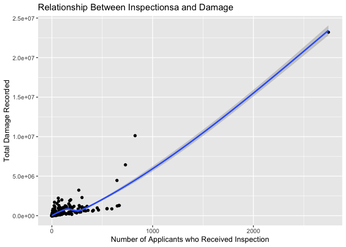

```r
ggplot(data = numdata) +
  geom_point(mapping = aes(x = totalInspected, y = totalDamage)) +
  geom_smooth(mapping = aes(x = totalInspected, y = totalDamage)) +
   labs(x = "Number of Applicants who Received Inspection", y= "Total Damage Recorded", title= "Relationship Between Inspectionsa and Damage")
```

Finally, in order to see which state had the highest amount of valid registrations, below shows a pie chart of the states and their proportions of numbers of valid registrations.

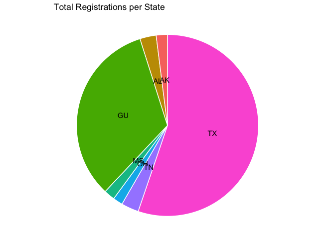

```r
#position of labels
labels <- numdata %>% arrange(desc(stateabb)) %>% summarize(totreg = sum(validRegistrations),.by = stateabb) %>% mutate(prop = totreg / sum(totreg)*100) %>% mutate(ypos = cumsum(prop) - 0.5*prop )

ggplot(labels,aes(x = "", y = prop, fill = stateabb)) +
  geom_bar(stat = "identity", width = 1, color = "white") +
  coord_polar( "y", start = 0) +
  theme_void() +
  theme(legend.position = "none") +
  geom_text(aes(y = ypos, label= stateabb ))  +
  labs(title = "Total Registrations per State")
```

## Emergency Management Performance Grants

This data contains information on funding given to U.S regions for assistance in preparing for disasters and hazards. The data is broken out by start date, predicted end date ,and closing year. Seeing that there are many different start dates, I would be interested to see how many states were recorded for each start year. Further, it would be interesting to see how much funding was given out per start year. Particularly, I would like to see how the funding values are distributed for the closing year and which states received large amounts of funding ( close to or over $5 million).

### Numerical Summaries

To see how how many states were recorded per start date, below shows a contingency table of start date per state. As can be seen, most of the projects were recorded in 2013 and 2014.

```r
numdata <- EMPData() %>% separate(startdate,c("Year", "Month", "Day"),sep = "-")

table(numdata$state,numdata$Year)
```

```
##
##                        2013 2014 2015 2016
##   Alabama                 0    1    0    0
##   Alaska                  1   13    0    0
##   American Samoa          0    1    0    0
##   Arizona                 0    2    0    0
##   Arkansas                0   75    1    0
##   California              0  109   11    0
##   Colorado                0   79    0    0
##   District of Columbia    1    0    0    0
##   Florida                 2   67   32    0
##   Hawaii                  0    5    0    0
##   Idaho                  44    1    0    0
##   Illinois              119    1    0    0
##   Indiana                 5  119   21    0
##   Iowa                    2    0    0    0
##   Kansas                  1    1    0    0
##   Kentucky                1    0    0    0
##   Louisiana              38   60   14    0
##   Maine                   1    0    0    0
##   Maryland               24   22    2    1
##   Michigan               95    1    0    0
##   Minnesota               0   26    1    0
```

To see how much funding was given out per start year, below will show data for the total funding per year. This summary agrees with the above contingency table where the most funding came from 2013 and 2014.

```r
numdata %>% summarize(TotalFunds = sum(fundingAmount), .by = Year)
```

| Year | TotalFunds |
| --- | --- |
| 2014 | 89586933 |
| 2013 | 50733926 |
| 2015 | 1390771 |
| 2016 | 1225 |

### Plots

We could see how much funding was provided per state. Below is a bar graph that shows how much funding was provided per state for funds greater than 5,000,000 dollars. From the results, California showed the most amount of funding at close to $30,000,000. I would be curious to know if that funding was for emergencies like forest fires, or other storm emergencies.

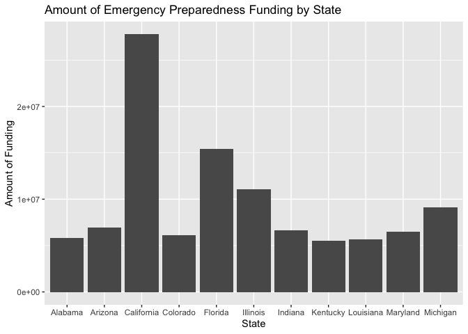

```r
numdata1 <-  EMPData() %>%
  summarise(TotalFunds = sum(fundingAmount), .by = state)  %>% filter ( TotalFunds > 5000000)

 ggplot(data=numdata1, aes(x=state,y=TotalFunds, )) +
  geom_bar(stat = "identity",position= position_dodge()) +
  labs(x = "State", y= "Amount of Funding", title= "Amount of Emergency Preparedness Funding by State")
```

Finally, since there was only one closeout year, I was interested to see how the data was distributed for smaller amounts of funding.

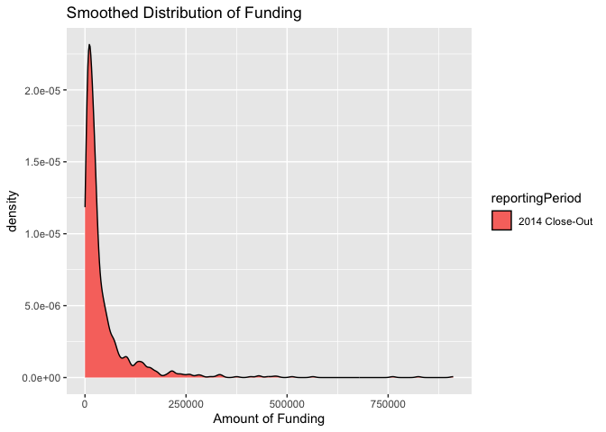

```r
numdata2 <- numdata %>% filter(fundingAmount < 1000000)
ggplot(numdata2)+
  geom_density(mapping=aes(x=fundingAmount, fill = reportingPeriod), position="identity") +
  labs(x = "Amount of Funding", title = "Smoothed Distribution of Funding")
```

# Wrap Up

In summary, I hope that this vignette provides and idea of how to connect to data from various endopoints of an API and to perform basic exploratory data analysis. There is a multitude of APIs to work with, but the FEMA data seemed to pull my interest, as it contained some important data on federal assistance to US states in preparation of and response to disasters - especially in light of some of the major natural disasters or severe weather occurances that have occured over the past years.